# The Central Limit Theorem

How very different populations can produce approximately normal sample means

## 1 Learning objectives

By the end of this lesson, you should be able to:

1. Distinguish a **population distribution**, a **sample distribution**, and a **sampling distribution**.
2. Explain the Central Limit Theorem in plain language.
3. Explain why larger samples usually produce more stable averages.
4. Use R to simulate repeated random sampling.
5. Compare simulated results with the theoretical predictions of the Central Limit Theorem.

**ImportantThe central idea**

The original population distribution does **not** become normal.

The **distribution of sample means** becomes approximately normal as the sample size increases—under the right conditions.

## 2 Begin with a question

Suppose individual customer wait times are strongly right-skewed. Most customers wait only a few minutes, but a few customers wait much longer.

> If we repeatedly select 30 customers and calculate their average wait time, what shape will the collection of sample averages have?

It may seem that the averages should remain strongly right-skewed because the individual wait times are right-skewed. The Central Limit Theorem gives us a surprising result.

## 3 Three distributions that must be kept separate

| Distribution | What it contains | Example |
| --- | --- | --- |
| Population distribution | All possible individual values | Every customer’s wait time |
| Sample distribution | Individual values in one sample | Wait times for 30 selected customers |
| Sampling distribution | A statistic calculated from each of many samples | The mean (of 30 selected customers) wait time from each of 10,000 samples |

The Central Limit Theorem concerns the **sampling distribution of the sample mean**.

**NoteOne sample is not a sampling distribution**

A single sample gives us one sample mean. To observe a sampling distribution, we need to imagine—or simulate—taking many samples and calculating the mean of every sample.

## 4 What does the Central Limit Theorem say?

Suppose a population has mean $\mu$ and standard deviation $\sigma$. We repeatedly take independent random samples of size $n$ and calculate the mean of each sample:

$$\bar X = \frac{X_1+X_2+\cdots+X_n}{n}.$$

As $n$ becomes sufficiently large, the sampling distribution of $\bar X$ becomes approximately normal:

$$\bar X \approx N\left(\mu,\frac{\sigma}{\sqrt{n}}\right).$$

This result tells us three important things.

### 4.1 1. The shape becomes approximately normal

The sampling distribution of the mean can become approximately normal even when the original population is not normal.

### 4.2 2. The center is the population mean

$$E(\bar X)=\mu.$$

Across repeated samples, the sample mean is centered on the population mean.

### 4.3 3. The spread becomes smaller

$$SD(\bar X)=\frac{\sigma}{\sqrt n}.$$

This standard deviation is called the **standard error of the mean**. Larger samples produce less variable—and therefore more precise—sample means.

**WarningIs n = 30 always enough?**

No. The rule that $n=30$ is sufficiently large is only a guideline. A symmetric population may require a smaller sample, while a strongly skewed or heavy-tailed population may require a much larger sample.

This number changes based on the original distribution. What is the number for popular distributions?

## 5 Simulating the CLT in R

We will begin with an exponential population because it is clearly right-skewed. With `rate = 1`, the population mean and standard deviation are both 1.

### 5.1 Step 1: Look at individual observations

**ImportantProject 1**

This is the key idea for Project 1

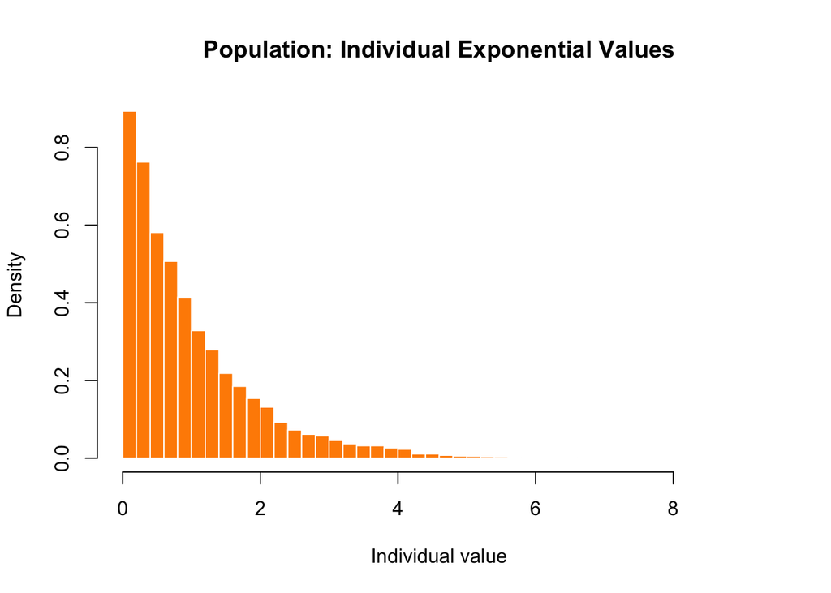

Individual values from a strongly right-skewed exponential population.

```r
# what does label and fig-cap do?

# What does this do? Prove what it does
set.seed(123)

# What does rexp generate?
# What is x?
x <- rexp(10000, rate = 1)

# Can you manually enter values for x?
hist(
  x,
  breaks = 40,
  probability = TRUE,
  col = "darkorange",
  border = "white",
  main = "Population: Individual Exponential Values",
  xlab = "Individual value"
)
```

The individual observations are strongly right-skewed. This population does not become normal during our experiment.

### 5.2 How random number generators work

Computers cannot generate truly random numbers — they use a **deterministic algorithm** that produces sequences of values that *look* random. The seed is the starting point for that algorithm. The same seed always produces the same sequence, which is why `set.seed(123)` makes results reproducible.

A classic example is the **Linear Congruential Generator (LCG)**, the basis of many early random number generators:

$$X_{n+1} = (a \cdot X_n + c) \mod m$$

Where:

- $X_0$ = the seed (starting value — this is what `set.seed(123)` sets)
- $a$ = multiplier
- $c$ = increment
- $m$ = modulus (keeps numbers within a fixed range)

**A concrete example:** Let $a = 5$, $c = 3$, $m = 16$, and seed $X_0 = 123 \mod 16 = 11$.

| Step | Formula | Result |
| --- | --- | --- |
| $X_1$ | $(5 \times 11 + 3) \mod 16$ | 10 |
| $X_2$ | $(5 \times 10 + 3) \mod 16$ | 5 |
| $X_3$ | $(5 \times 5 + 3) \mod 16$ | 12 |
| $X_4$ | $(5 \times 12 + 3) \mod 16$ | 15 |

Each output feeds directly into the next — fully determined by the seed. Change the seed and you get a completely different sequence.

```r
lcg <- function(seed, a = 5, c = 3, m = 16, n = 4) {
  x <- numeric(n) #create a vector
  x[1] <- (a * seed + c) %% m # assign first based on seed
  for (i in 2:n) x[i] <- (a * x[i - 1] + c) %% m
  x # print the vector after the for loop
}

# Let's learn functions! Can we input different numbers here?

lcg(seed = 11)
```

```
[1] 10  5 12 15
```

R’s actual generator (Mersenne Twister) uses the same principle but with far larger values of $m$, producing sequences so long they never repeat in practice and are impossible to predict without knowing the seed.

### 5.3 Step 2: Take one random sample

```r
set.seed(123)

one_sample <- rexp(5, rate = 1)

# why round?
round(one_sample, 3)
```

```
[1] 0.843 0.577 1.329 0.032 0.056
```

```r
# why not round here?
mean(one_sample)
```

```
[1] 0.5673821
```

This gives us five individual observations and **one** sample mean. We still do not have a sampling distribution.

### 5.4 Step 3: Repeat the sampling process

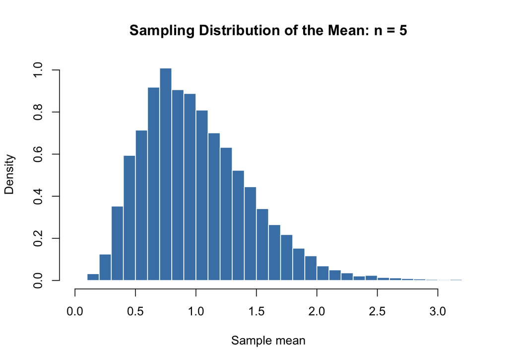

The sampling distribution produced from 10,000 samples of size 5.

```r
set.seed(123)

# what does replicate do?
# run some examples manually
sample_means <- replicate(
  10000,
  mean(rexp(5, rate = 1))
)

hist(
  sample_means,
  breaks = 40,       # what does this do?
  probability = TRUE, # what does this do?
  col = "steelblue",
  border = "white",
  main = "Sampling Distribution of the Mean: n = 5",
  xlab = "Sample mean"
)
```

The important expression is:

```r
replicate(10000, mean(rexp(5, rate = 1)))
```

R performs the following steps:

1. Generate five observations from an exponential distribution.
2. Calculate their mean.
3. Repeat the process 10,000 times.
4. Save the 10,000 sample means.

## 6 What happens as the sample size increases?

We will create 10,000 sample means at four different sample sizes.

```r
set.seed(123)

# what are these going to produce if i print them out?

means_n2 <- replicate(10000, mean(rexp(2, rate = 1)))
means_n5 <- replicate(10000, mean(rexp(5, rate = 1)))
means_n30 <- replicate(10000, mean(rexp(30, rate = 1)))
means_n100 <- replicate(10000, mean(rexp(100, rate = 1)))
```

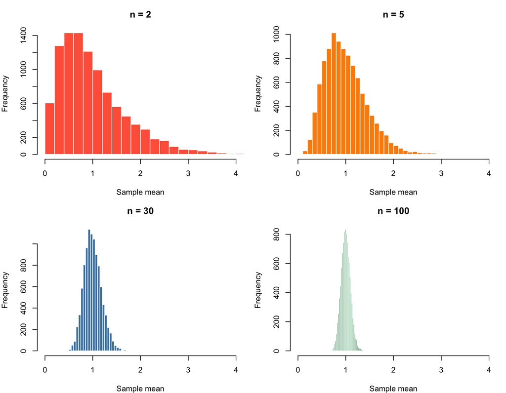

As sample size increases, the sampling distribution becomes more normal and less spread out.

```r
old_par <- par(
  mfrow = c(2, 2),
  mar = c(4, 4, 3, 1)
)

hist(means_n2, breaks = 40, col = "tomato", border = "white",
     main = "n = 2", xlab = "Sample mean", xlim = c(0, 4))

hist(means_n5, breaks = 40, col = "darkorange", border = "white",
     main = "n = 5", xlab = "Sample mean", xlim = c(0, 4))

hist(means_n30, breaks = 40, col = "steelblue", border = "white",
     main = "n = 30", xlab = "Sample mean", xlim = c(0, 4))

hist(means_n100, breaks = 40, col = "seagreen", border = "white",
     main = "n = 100", xlab = "Sample mean", xlim = c(0, 4))
```

```r
par(old_par)
```

As $n$ increases:

1. What happens to the shape of the sampling distribution?
2. What happens to its center?
3. What happens to its spread?
4. Did the original exponential population change?

The sampling distribution becomes more normal and narrower. Its center remains near 1, the population mean.

## 7 How to tell if a distribution is normal

**ImportantProject 1**

This is the key idea for Project 1

As sample size increases, the CLT predicts the sampling distribution of the mean will approach normality. We can test that prediction directly using five diagnostics applied to each of the four sampling distributions.

### 7.1 Histograms with theoretical normal curve

Each histogram shows the simulated sampling distribution. The red curve is the normal distribution predicted by the CLT: $N(1,\ 1/\sqrt{n})$.

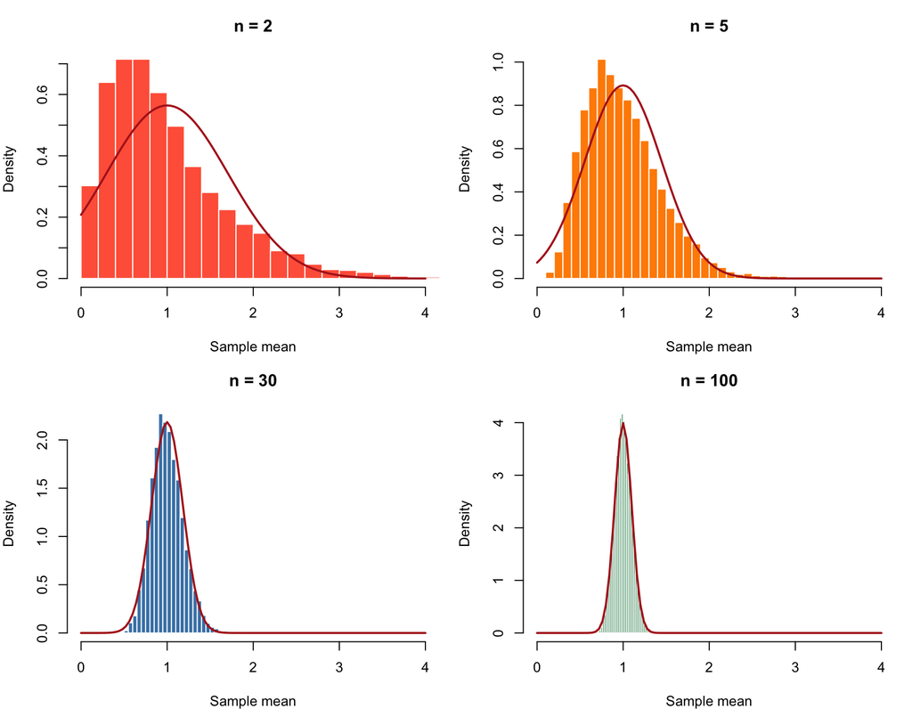

Simulated sampling distributions (bars) with the CLT-predicted normal curve (red) overlaid.

```r
configs <- list(
  list(dat = means_n2,   n = 2,   col = "tomato"),
  list(dat = means_n5,   n = 5,   col = "darkorange"),
  list(dat = means_n30,  n = 30,  col = "steelblue"),
  list(dat = means_n100, n = 100, col = "seagreen")
)

old_par <- par(mfrow = c(2, 2), mar = c(4, 4, 3, 1))

for (cfg in configs) {
  hist(cfg$dat, breaks = 40, probability = TRUE,
       col = cfg$col, border = "white",
       main = paste("n =", cfg$n), xlab = "Sample mean",
       xlim = c(0, 4))
  curve(dnorm(x, mean = 1, sd = 1 / sqrt(cfg$n)),
        add = TRUE, col = "firebrick", lwd = 2)
}
```

```r
par(old_par)
```

### 7.2 Normal Q–Q plots

Points falling close to the diagonal line indicate approximate normality. Deviations at the ends reveal heavy tails; a curve through the middle suggests skew.

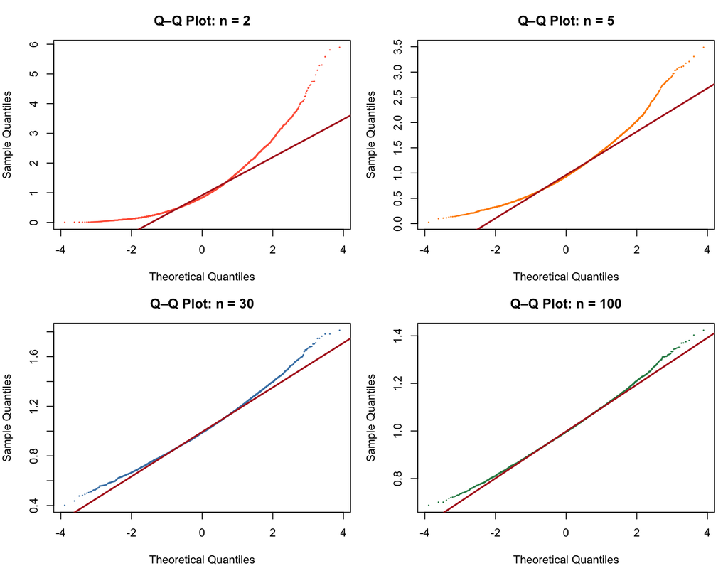

Q–Q plots for each sampling distribution.

```r
old_par <- par(mfrow = c(2, 2), mar = c(4, 4, 3, 1))

for (cfg in configs) {
  qqnorm(cfg$dat, main = paste("Q–Q Plot: n =", cfg$n),
         col = cfg$col, pch = 16, cex = 0.3)
  qqline(cfg$dat, col = "firebrick", lwd = 2)
}
```

```r
par(old_par)
```

### 7.3 Skewness

A perfectly normal distribution has skewness of 0. Positive skewness means a right tail; negative means a left tail.

```r
skew <- function(x) {
  m3 <- mean((x - mean(x))^3)
  m2 <- mean((x - mean(x))^2)
  m3 / m2^(3/2)
}

data.frame(
  sample_size = c(2, 5, 30, 100),
  skewness    = round(sapply(list(means_n2, means_n5, means_n30, means_n100), skew), 3)
)
```

```
  sample_size skewness
1           2    1.384
2           5    0.897
3          30    0.393
4         100    0.234
```

Skewness should shrink toward 0 as $n$ increases, reflecting the approach to normality predicted by the CLT.

### 7.4 Kurtosis

Kurtosis measures the heaviness of a distribution’s tails relative to a normal distribution. We use **excess kurtosis**, which subtracts 3 so that a normal distribution scores exactly 0:

$$\text{Excess kurtosis} = \frac{\frac{1}{n}\sum(x_i - \bar x)^4}{\left[\frac{1}{n}\sum(x_i - \bar x)^2\right]^2} - 3$$

- **0** — tails match a normal distribution
- **Positive** — heavier tails than normal (more extreme values)
- **Negative** — lighter tails than normal

```r
kurt <- function(x) {
  m4 <- mean((x - mean(x))^4)
  m2 <- mean((x - mean(x))^2)
  m4 / m2^2 - 3
}

data.frame(
  sample_size = c(2, 5, 30, 100),
  excess_kurtosis = round(sapply(list(means_n2, means_n5, means_n30, means_n100), kurt), 3)
)
```

```
  sample_size excess_kurtosis
1           2           2.803
2           5           1.259
3          30           0.274
4         100           0.137
```

Excess kurtosis should shrink toward 0 as $n$ increases, just like skewness. The exponential population has an excess kurtosis of 6 — heavily right-tailed. As the CLT takes hold, the sampling distribution sheds those heavy tails and approaches the normal baseline of 0.

### 7.5 Shapiro–Wilk test

The null hypothesis is that the data are normally distributed. A small p-value is evidence against normality.

Because `shapiro.test()` requires $n \leq 5{,}000$, we test a random subsample of 5,000 draws from each vector.

```r
set.seed(7391)

sw <- function(x) {
  result <- shapiro.test(sample(x, 5000))
  c(W = round(result$statistic, 4), p_value = round(result$p.value, 4))
}

sw_results <- do.call(
  rbind,
  lapply(list(means_n2, means_n5, means_n30, means_n100), sw)
)

data.frame(sample_size = c(2, 5, 30, 100), sw_results, row.names = NULL)
```

```
  sample_size    W.W p_value
1           2 0.9025       0
2           5 0.9532       0
3          30 0.9919       0
4         100 0.9964       0
```

As $n$ increases, $W$ should approach 1 and the p-value should rise, reflecting less evidence against normality. For large enough $n$, the Shapiro–Wilk test may still reject normality due to sensitivity — use it alongside the Q–Q plot and histogram rather than in isolation.

## 8 Compare the simulation with theory

For an exponential distribution with `rate = 1`:

$$\mu=1 \qquad \text{and} \qquad \sigma=1.$$

For $n=30$, the theoretical standard error is:

$$SE=\frac{\sigma}{\sqrt n}=\frac{1}{\sqrt{30}}\approx 0.183.$$

```r
mean(means_n30)
```

```
[1] 0.9990063
```

```r
sd(means_n30)
```

```
[1] 0.1829993
```

```r
1
```

```
[1] 1
```

```r
1 / sqrt(30)
```

```
[1] 0.1825742
```

Now compare every sample size.

```r
results <- data.frame(
  sample_size = c(2, 5, 30, 100),
  simulated_mean = c(
    mean(means_n2),
    mean(means_n5),
    mean(means_n30),
    mean(means_n100)
  ),
  simulated_sd = c(
    sd(means_n2),
    sd(means_n5),
    sd(means_n30),
    sd(means_n100)
  ),
  theoretical_sd = 1 / sqrt(c(2, 5, 30, 100))
)

round(results, 3)
```

```
  sample_size simulated_mean simulated_sd theoretical_sd
1           2          1.003        0.705          0.707
2           5          0.997        0.442          0.447
3          30          0.999        0.183          0.183
4         100          1.000        0.099          0.100
```

The simulated means should be close to 1. The simulated standard deviations should be close to the theoretical standard errors.

### 8.1 Add the theoretical normal curve

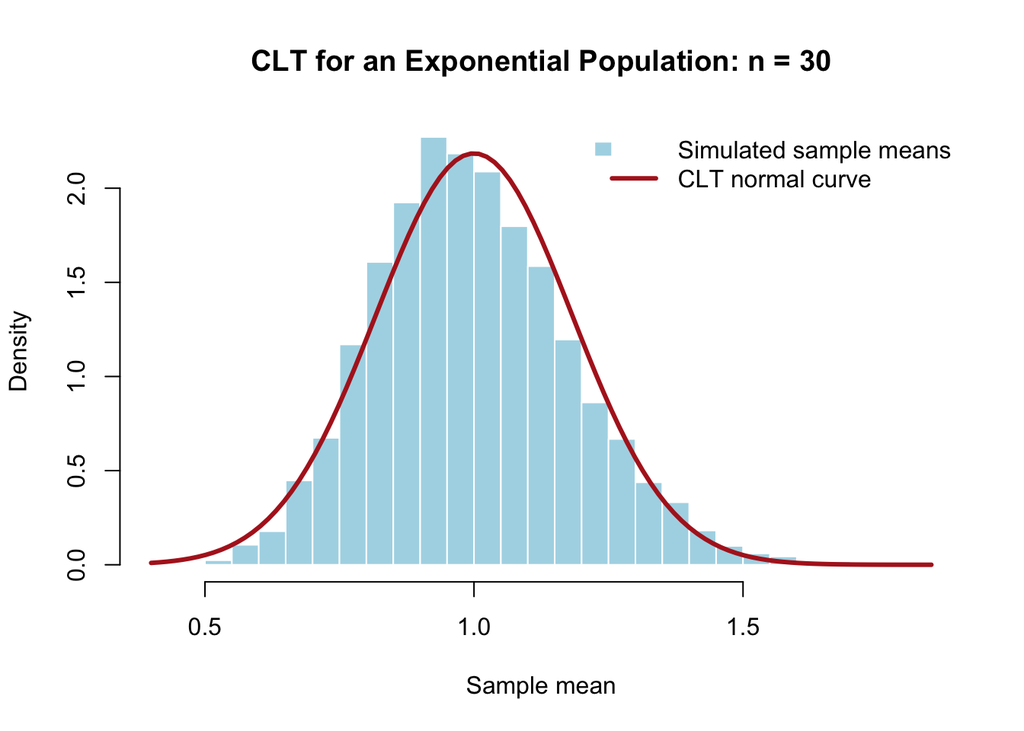

The simulated sample means and the normal curve predicted by the CLT.

```r
hist(
  means_n30,
  breaks = 40,
  probability = TRUE,
  col = "lightblue",
  border = "white",
  main = "CLT for an Exponential Population: n = 30",
  xlab = "Sample mean"
)

curve(
  dnorm(x, mean = 1, sd = 1 / sqrt(30)),
  add = TRUE,
  col = "firebrick",
  lwd = 3
)

legend(
  "topright",
  legend = c("Simulated sample means", "CLT normal curve"),
  fill = c("lightblue", NA),
  border = c("white", NA),
  lty = c(NA, 1),
  lwd = c(NA, 3),
  col = c(NA, "firebrick"),
  bty = "n"
)
```

The histogram is produced by simulation. The red curve is the normal distribution predicted by the Central Limit Theorem.

## 9 Starting with different population distributions

The Central Limit Theorem is not limited to exponential populations. We can begin with continuous, discrete, symmetric, or skewed distributions.

```r
set.seed(123)

normal_means <- replicate(10000, mean(rnorm(30)))
uniform_means <- replicate(10000, mean(runif(30)))
exponential_means <- replicate(10000, mean(rexp(30)))
poisson_means <- replicate(10000, mean(rpois(30, lambda = 1)))
```

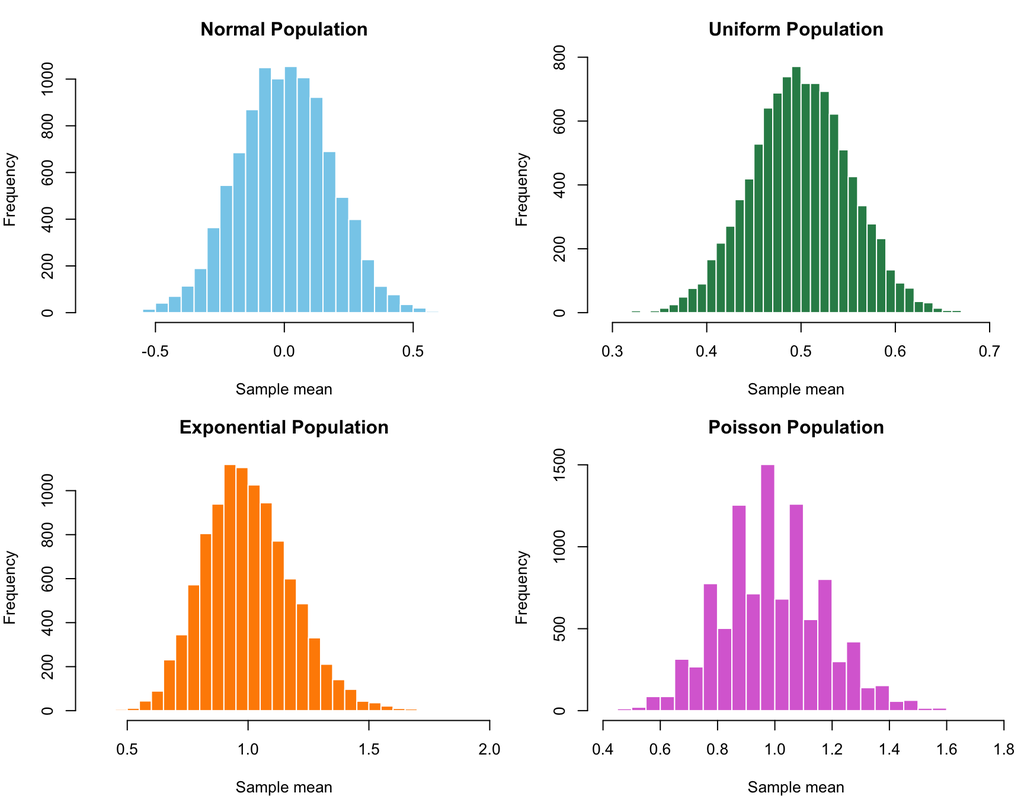

Sampling distributions of the mean from four different populations, using n = 30.

```r
old_par <- par(
  mfrow = c(2, 2),
  mar = c(4, 4, 3, 1)
)

hist(normal_means, breaks = 40, col = "skyblue", border = "white",
     main = "Normal Population", xlab = "Sample mean")

hist(uniform_means, breaks = 40, col = "seagreen", border = "white",
     main = "Uniform Population", xlab = "Sample mean")

hist(exponential_means, breaks = 40, col = "darkorange", border = "white",
     main = "Exponential Population", xlab = "Sample mean")

hist(poisson_means, breaks = 40, col = "orchid", border = "white",
     main = "Poisson Population", xlab = "Sample mean")
```

```r
par(old_par)
```

Important observations:

- A normal population produces normal sample means for every sample size.
- Symmetric distributions usually approach normality quickly.
- Strongly skewed distributions may require larger samples.
- Discrete populations can still produce approximately normal sample means.
- The statement that “$n=30$ is enough” is a guideline, not a theorem.

## 10 Why is the Central Limit Theorem important?

Usually, we do not know the entire population. We have only one sample. The CLT helps us describe how a sample mean would vary if we repeatedly collected new samples.

This makes it possible to construct and interpret:

- Standard errors
- Margins of error
- Confidence intervals
- Hypothesis tests
- Many regression and statistical models

For example, an approximate 95% range for a sample mean is:

$$\mu \pm 1.96\frac{\sigma}{\sqrt n}.$$

Without the Central Limit Theorem, we could still calculate a sample mean, but it would be much harder to determine how precise or reliable it is.

## 11 Student activity: Test the CLT

Choose or receive one of the following starting distributions:

- Uniform
- Binomial
- Poisson
- Exponential
- Beta
- Normal
- Cauchy as a special challenge

Complete the following analysis:

1. Generate and plot 10,000 individual values from your population.
2. Describe the population’s shape, center, and spread.
3. Simulate 10,000 sample means for $n=2,5,10,30,$ and $100$.
4. Plot the five sampling distributions using the same horizontal scale when practical.
5. Compare their shapes, centers, and spreads.
6. Decide when the sampling distribution appears approximately normal.
7. Compare the simulated standard deviation with $\sigma/\sqrt n$.
8. Explain whether the Central Limit Theorem worked for your distribution and why.
9. Identify evidence that would cause you to revise your conclusion.

If the original population did not change, why did the distribution of sample means change?

## 12 Summary

The Central Limit Theorem does **not** say that all data become normally distributed. It says that, under appropriate conditions, the distribution of sample means becomes approximately normal as the sample size increases.

As $n$ increases:

- The sampling distribution becomes more normal.
- Its center remains at the population mean $\mu$.
- Its standard deviation decreases according to $\sigma/\sqrt n$.
- Sample means become more stable and precise.

The CLT is one of the most important bridges between probability and statistical inference. It allows us to use sample data to make defensible statements about populations.